# The O2DIA package - early diagenetic modelling of the O2 cycle

Karline Soetaert, Li Qiu, Lubos Polerecky

04-July-2024

# O2DIA

The O2DIA model is a 1-D model of oxygen diagenesis in aquatic sediments.

```r
require(O2DIA)
```

The O2DIA package contains functions to generate (a time series of) vertical, one dimensional (1DV) diagenetic profiles. It can either be run in dynamic mode, or the steady-state solution can be estimated. It contains several utility functions, e.g. to help in extracting information on the model output, or to estimate mass budgets.

The package contains the following functions:

```r
ls("package:O2DIA")
```

```
##  [1] "O2DIA0D"       "O2DIA1D"       "O2DIAbudgetO2" "O2DIAdepth"    "O2DIAdx"       "O2DIAdyna"     "O2DIAgrid"
##  [8] "O2DIAparms"    "O2DIApor"      "O2DIAsteady"   "O2DIAsvar"     "matplot1D"
```

# Main functions

The main functions allow to solve the model to steady state (*O2DIAsteady*), or to run it dynamically (*O2DIAdyna*).

## Steady-state solution, function O2DIAsteady

Function *O2DIAsteady* finds the steady-state solution of the O2DIA model. Its arguments are:

```r
args(O2DIAsteady)
```

```
function (parms = list(), yini = NULL, Grid = NULL, times = 0,
    Temperature = 10, PAR0 = 1000, Waterheight = 0.01, Tfunction = "Q10")
NULL
```

here *parms* is a list with a subset of the O2DIA parameters (see appendix for what they mean and their default values). If a parameter is unspecified, then the default value is used.

## Dynamic run, function O2DIAdyna

Function *O2DIAdyna* runs the O2DIA model for a specific time interval and produces output at requested times. Its arguments are:

```r
args(O2DIAdyna)
```

```
function (parms = list(), times = seq(0, 1, length.out = 10),
    yini = NULL, Grid = NULL, Temperature = 10, PAR0 = 1000,
    Waterheight = 0.01, Tfunction = "Q10", verbose = FALSE)
NULL
```

The function to run the model dynamically also allows for several external conditions to be either constants or to vary in time: Temperature, PAR0 and Waterheight. These forcing functions are either prescribed as a data series or a function that takes time as its input argument.

# Accessory functions

## showing the parameter values

The values of the parameters, and their units can be interrogated:

```r
P  <- O2DIAparms()
head(P)
```

```
##            parms  units                              description
## x_DBL    2.0e-04      m   thickness of diffusive boundary layer
## x_down   1.0e-02      m                    thickness of sediment
## por      9.0e-01      -                      volumetric porosity
## salinity 3.1e+01      -                                 salinity
## v_adv    0.0e+00    m/d sediment accretion (=advection) velocity
## ks_min   1.0e-05 mol/m3                              O2 affinity
```

See the appendix for a complete list of the parameters.

Also the parameter settings of a dynamic run can be output:

```r
DYN <- O2DIAdyna()
head(O2DIAparms(DYN))
```

```
##            parms  units                              description
## x_DBL    2.0e-04      m   thickness of diffusive boundary layer
## x_down   1.0e-02      m                    thickness of sediment
## por      9.0e-01      -                      volumetric porosity
## salinity 3.1e+01      -                                 salinity
## v_adv    0.0e+00    m/d sediment accretion (=advection) velocity
## ks_min   1.0e-05 mol/m3                              O2 affinity
```

```r
O2DIAparms(DYN, which = "Q10_min")
```

```
##         parms units                                       description
## Q10_min   2.4     - Q10 coefficient growth respiration+mineralisation
```

## Budgets

Once the model is solved, it is possible to calculate budgets of the O2 cycle (*O2DIAbudgetO2*).

```r
std <- O2DIAsteady()

print(O2DIAbudgetO2(std))
```

```
## $Rates
##            O2Production Growthresp_min    Basalresp Photoresp ODUreoxidation TotalConsumption NetConsumption
## molO2/m2/d     4.769054     0.04769023 0.0009957702  3.931728      0.2927474         4.273162     -0.4958929
##
## $Fluxes
##                   O2        ODU
## surface   -0.4958929 -0.1256621
## bottom     0.0000000 -0.4184095
## netinflux -0.4958929  0.2927474
##
## $dC
##           O2          ODU
## 9.803269e-14 9.542367e-14
```

where all fluxes are in *mol/m2/day*.

## Properties of solutions

There are functions to retrieve several properties of the solution:

- *O2DIAdepth*, *O2DIAdx*, *O2DIAgrid* retrieve the sediment depths, layer thicknesses and grid of *O2DIA* model solutions.
- *O2DIAparms* retrieves the parameter settings of *O2DIA* model solutions.
- *O2DIA0D* and *O2DIA1D* return the output variables of the solution as a vector or data.frame. For dynamic runs, the output is averaged over the mean of the run. *O2DIA1D* always returns the sediment depth and the porosity as the first two columns.

```r
range(O2DIAdx(std))
```

```
## [1] 9.977673e-07 1.867610e-04
```

```r
range(O2DIAgrid()$x.int)
```

[output not shown]

```r
head(O2DIAdepth(std))
```

```
## [1] -0.0001995000 -0.0001983972 -0.0001970675 -0.0001954643 -0.0001935314 -0.0001912010
```

Profiles of one-dimensional variables can be extracted with *O2DIA1D*:

```r
head(O2DIA1D(std), n = 3)
```

```
##               x por        O2          ODU O2consumption O2prod O2min O2reox O2basalresp O2photoresp ODUconsumption
## 1 -0.0001995000   1 0.2914601 0.0005909428             0      0     0      0           0           0              0
## 2 -0.0001983972   1 0.2952572 0.0018943749             0      0     0      0           0           0              0
## 3 -0.0001970675   1 0.2998354 0.0034659004             0      0     0      0           0           0              0
##   BioDist Light kext PI
## 1       0  1000  0.1  0
## 2       0  1000  0.1  0
## 3       0  1000  0.1  0
```

# Steady-state applications

The function *O2DIAsteady* solves for a steady-state condition.

## Simple applications

In the frst example, we run the model for several temperatures using *rootSolve*’s *plot* function.

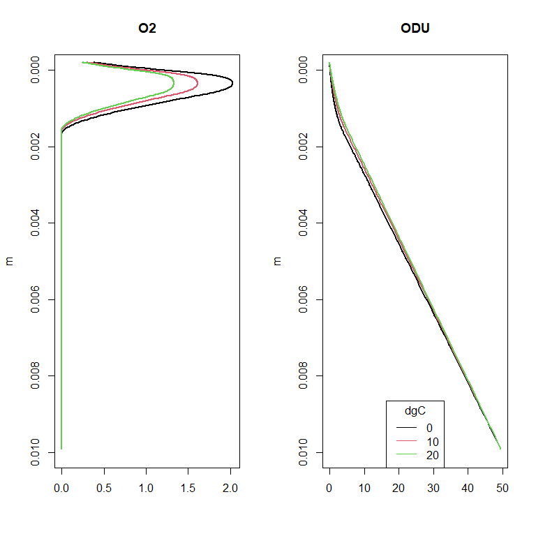

```r
STD1 <- O2DIAsteady (Temperature =  0)
STD2 <- O2DIAsteady (Temperature = 10)
STD3 <- O2DIAsteady (Temperature = 20)
plot(STD1, STD2, STD3,
     which = c("O2", "ODU"),
     ylim  = c(0.01, 0), lty = 1, lwd = 2)
legend("bottom", legend = c(0, 10, 20), title = "dgC",
       lty = 1, col = 1:3)
```

## Dry flats, moist sediment

The exchange of substances at the upper interface can take on two modes:

- exchange with water overlying the sediment or
- exchange with the atmosphere.

When flats are not exposed to overlying water, the exchange with the atmosphere for O2 BUT NOT FOR ODU is much faster. Also, the microphytobenthos production rate is much lower (according to parameter *prodfacdry*)

```r
O2DIAparms(which = "prodfacdry")
```

```
##            parms units                                      description
## prodfacdry   0.4     - fraction of photosynthesis during dry conditions
```

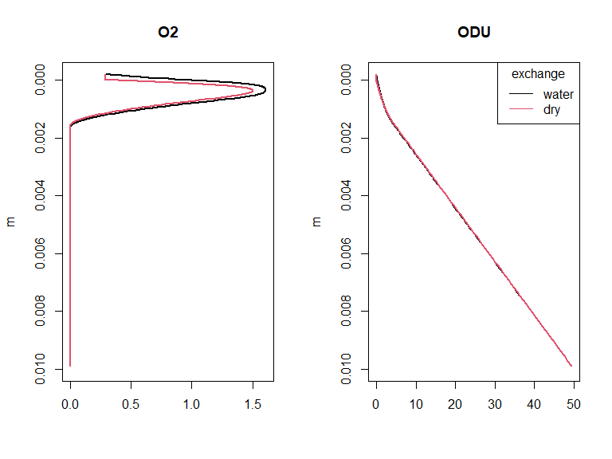

```r
out    <- O2DIAsteady()
outdry <- O2DIAsteady(Waterheight = 0)

plot(out, outdry,
     which = c("O2", "ODU"),
     lty = 1, lwd = 2)
legend("topright", title = "exchange", legend = c("water","dry"),
       col = 1:2, lty = 1)
```

```r
print(O2DIAbudgetO2(out, outdry))
```

```
## $Rates
##                            out        outdry
## O2Production      4.7690544365  1.9076229192
## Growthresp_min    0.0476902335  0.0190760814
## Basalresp         0.0009957702  0.0009957689
## Photoresp         3.9317281645  0.9975234738
## ODUreoxidation    0.2927473987  0.2669676505
## TotalConsumption  4.2731615670  1.2845629747
## NetConsumption   -0.4958928695 -0.6230599445
##
## $Fluxes
##                out     outdry
## O2surf  -0.4958929 -0.6230599
## O2deep   0.0000000  0.0000000
## O2net   -0.4958929 -0.6230599
## ODUsurf -0.1256621 -0.1499137
## ODUdeep -0.4184095 -0.4168813
## ODUnet   0.2927474  0.2669677
##
## $dC
##              out        outdry
## O2  9.447998e-14 -6.839018e-11
## ODU 9.164891e-14  3.154144e-13
```

# Dynamic runs with sinusoidal forcing

## Light intensity

In the first dynamic run, a sinusoidal variation in time is used for the light; the sediment remains inundated.

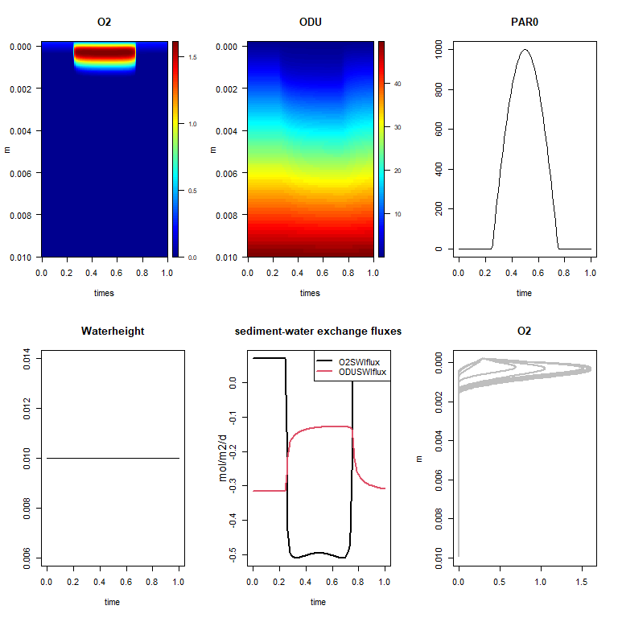

```r
times    <- seq (0, 1, length.out = 100)
PAR0_fun <- function(t) pmax(0, 1000*sin(2*pi*t - pi/2))

DIA <- O2DIAdyna (times = times,
                  PAR0 = PAR0_fun)

image2D(DIA,
        mfrow = c(2, 3), las = 1)

plot(DIA, which = c("PAR0", "Waterheight"), mfrow=NULL)
matplot.0D(DIA,
           which = c("O2SWIflux", "ODUSWIflux"),
           main = "sediment-water exchange fluxes",
           ylab = "mol/m2/d",
           mfrow = NULL, lty = 1, lwd = 2)
matplot1D(DIA, which = c("O2"),
     mfrow = NULL, lwd = 2)
```

In the first dynamic run, a sinusoidal variation in time is used for the light; the sediment is dry

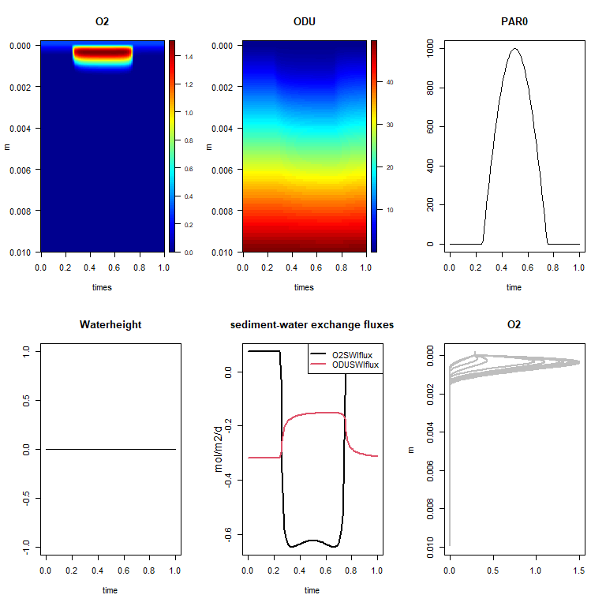

```r
DIA2 <- O2DIAdyna (times = times,
                  PAR0 = PAR0_fun,
                  Waterheight = 0)

image2D(DIA2,
        mfrow = c(2, 3), las = 1)

plot(DIA2, which = c("PAR0", "Waterheight"), mfrow=NULL)
matplot.0D(DIA2,
           which = c("O2SWIflux", "ODUSWIflux"),
           main = "sediment-water exchange fluxes",
           ylab = "mol/m2/d",
           mfrow = NULL, lty = 1, lwd = 2)
matplot1D(DIA2, which = c("O2"),
     mfrow = NULL, lwd = 2)
```

The budgets for the two runs are compared

```r
O2DIAbudgetO2(DIA, DIA2)
```

```
## $Rates
##                            DIA         DIA2
## O2Production      2.1719977096  0.868799605
## Growthresp_min    0.0217198342  0.008687925
## Basalresp         0.0009430903  0.000986518
## Photoresp         1.7552592811  0.426795385
## ODUreoxidation    0.1835998861  0.168540254
## TotalConsumption  1.9615220916  0.605010082
## NetConsumption   -0.2104756179 -0.263789523
##
## $Fluxes
##                DIA       DIA2
## O2surf  -0.2114977 -0.2641813
## O2deep   0.0000000  0.0000000
## O2net   -0.2114977 -0.2641813
## ODUsurf -0.2188841 -0.2352182
## ODUdeep -0.4010388 -0.4026816
## ODUnet   0.1821547  0.1674633
##
## $dC
##              DIA          DIA2
## O2  -0.001022098 -0.0003917756
## ODU -0.001445145 -0.0010769233
```

## Water height and light intensity

On top of the light intensity variation, also the water height changes. The light intensity is also affected by the water height (extinction coefficient 1/m)

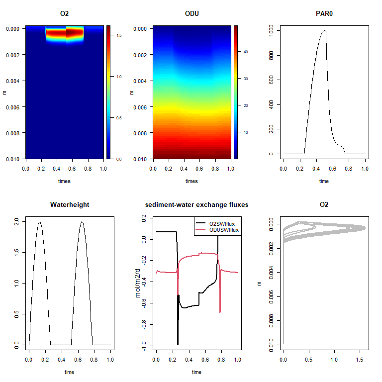

```r
times    <- seq (0, 1, length.out = 100)
WH_fun <- function(t) pmax(0, 2*sin(2*pi*t/0.517))  # tidal period = 12.4/24 days
PAR0_fun <- function(t) pmax(0, 1000*sin(2*pi*t - pi/2))*exp(-1*WH_fun(t))

DIA3 <- O2DIAdyna (times = times,
                  Waterheight = WH_fun,
                  PAR0 = PAR0_fun)

image2D(DIA3,
        mfrow = c(2, 3), las = 1)

plot(DIA3, which = c("PAR0", "Waterheight"), mfrow=NULL)
matplot.0D(DIA3,
           which = c("O2SWIflux", "ODUSWIflux"),
           main = "sediment-water exchange fluxes",
           ylab = "mol/m2/d",
           mfrow = NULL, lty = 1, lwd = 2)
matplot1D(DIA3, which = c("O2"),
     mfrow = NULL, lwd = 2)
```

# References

# APPENDIX

## Parameters and default values.

```r
knitr:::kable(O2DIAparms())
```

|  | parms | units | description |
| --- | --- | --- | --- |
| x_DBL | 2.00e-04 | m | thickness of diffusive boundary layer |
| x_down | 1.00e-02 | m | thickness of sediment |
| por | 9.00e-01 | - | volumetric porosity |
| salinity | 3.10e+01 | - | salinity |
| v_adv | 0.00e+00 | m/d | sediment accretion (=advection) velocity |
| ks_min | 1.00e-05 | mol/m3 | O2 affinity |
| ks_odureox | 1.00e-05 | mol/m3 | O2 limitation in ODU oxydation |
| ks_basalresp | 1.00e-05 | mol/m3 | O2 limitation in dark respiration |
| ks_WL | 1.00e-05 | m | limitation of GPP by water level in GPP-water level relation |
| biomass | 1.00e+00 | molC/m2 | MPB biomass |
| c_min0 | 1.00e-02 | - | growth respiration fraction (function of photosynthesis) |
| r_odureox0 | 1.00e+02 | - | 1-order ODU reoxidation rate at T0 |
| r_mpbprod0 | 5.00e+01 | /d | 1-order O2 production rate at T0 (photosynthesis) |
| r_basalresp0 | 1.00e-02 | /d | 1-order O2 dark respiration rate at T0 |
| c_photoresp0 | 1.00e-03 | /d | O2 photorespiration fraction (function of photosynthesis) |
| kext_w | 1.00e-01 | /m | light extinction coefficient in water |
| kext_s | 2.00e+04 | /m | light extinction coefficient in sediment |
| ki_PI | 4.00e+02 | umol/m2/s | optimal light intensity in photosynthesis |
| cc_PI | 1.00e+00 | - | parameter to determine the shape of P-I curve |
| mu_bio | 3.00e-04 | m | the depth of maximum microphytobenthos biomass |
| sd_bio | 1.50e-04 | m | the standard deviation of mpb biomass distribution |
| deepODU | 5.00e+01 | mol/m3 | lower boundary concentration of ODU |
| m_photoresp | 4.00e+00 | - | order of photorespiration vs. O2 |
| prodfacdry | 4.00e-01 | - | fraction of photosynthesis during dry conditions |
| T0 | 1.00e+01 | dgC | Q10 base temperature |
| Q10_min | 2.40e+00 | - | Q10 coefficient growth respiration+mineralisation |
| Q10_odureox | 1.00e+00 | - | Q10 coefficient reoxidation |
| Q10_mpbprod | 1.47e+00 | - | Q10 coefficient photosynthesis |
| Q10_basalresp | 1.00e+00 | - | Q10 coefficient dark respiration |
| Q10_photoresp | 1.00e+00 | - | Q10 coefficient photorespiration |
| Tmax_MPBprod | 4.20e+01 | dgC | Max temperature where photosynthesis = 0 |
| Tmin_MPBprod | -1.50e+01 | dgC | Min temperature where photosynthesis = 0 |
| Topt_MPBprod | 3.70e+01 | dgC | Optimal temperature for photosynthesis |
| Tmax_min | 4.40e+01 | dgC | Max temperature where mineralisation = 0 |
| Tmin_min | 1.00e+01 | dgC | Min temperature where mineralisation = 0 |
| Topt_min | 3.50e+01 | dgC | Optimal temperature for mineralisation |
| Tmax_odureox | 5.50e+01 | dgC | Max temperature where odu reoxidation = 0 |
| Tmin_odureox | 0.00e+00 | dgC | Min temperature where odu reoxidation = 0 |
| Topt_odureox | 3.80e+01 | dgC | Optimal temperature for odu reoxidation rate |
| Tmax_basalresp | 4.50e+01 | dgC | Max temperature where basal respiration = 0 |
| Tmin_basalresp | 1.00e+01 | dgC | Min temperature where basal respiration = 0 |
| Topt_basalresp | 3.50e+01 | dgC | Optimal temperature for basal respiration |
| Tmax_photoresp | 4.10e+01 | dgC | Max temperature where photorespiration = 0 |
| Tmin_photoresp | 1.20e+01 | dgC | Min temperature where photorespiration = 0 |
| Topt_photoresp | 3.60e+01 | dgC | Optimal temperature for photorespiration |
| psat_O2 | 1.00e+00 | - | saturation fraction of bottom water oxygen |

## State variables

```r
knitr:::kable(O2DIAsvar())
```

| names | units | description |
| --- | --- | --- |
| O2 | molO2/m3 liquid | Oxygen (liquid) |
| ODU | molO2/m3 liquid | Oxygen Demand Units (liquid) |

## Zero-D ordinary variables

```r
knitr:::kable(O2DIA0D())
```

| names | values | units | description |
| --- | --- | --- | --- |
| Totalcons | NA | molO2/m2/d | Total oxygen consumption |
| Totalmin | NA | molO2/m2/d | Total oxygen consumption by growth respiration+mineralisation |
| Totalbasalresp | NA | molO2/m2/d | Total oxygen consumption by dark (basal) respiration |
| Totalphotoresp | NA | molO2/m2/d | Total oxygen consumption by photo respiration |
| Totalodureox | NA | molO2/m2/d | Total oxygen consumption by ODU reoxidation |
| Totalprod | NA | molO2/m2/d | Total oxygen production by photosynthesis |
| rODUreox | NA | molO2/m2/d | actual rate of ODU reoxidation |
| rMPBprod | NA | molO2/m2/d | actual rate of MPB production |
| rbasalresp | NA | molO2/m2/d | actual rate of basal respiration |
| O2SWIflux | NA | molO2/m2/d | O2 influx sediment-water |
| O2deepflux | NA | molO2/m2/d | O2 efflux lower boundary |
| ODUSWIflux | NA | molO2/m2/d | ODU influx sediment-water |
| ODUdeepflux | NA | molO2/m2/d | ODU efflux lower boundary |
| Temperature | NA | dgC | Sediment temperature |
| PAR0 | NA | uEinst/m2/s | PAR (Light) on top of sediment |
| Waterheight | NA | m | Bottom water height |

## One-D ordinary variables

```r
knitr:::kable(O2DIA1D())
```

| names | units | description |
| --- | --- | --- |
| O2 | molO2/m3 liquid | Oxygen (liquid) |
| ODU | molO2/m3 liquid | Oxygen Demand Units (liquid) |
| O2consumption | molO2/m3 liquid/d | profile of Total oxygen consumption |
| O2prod | molO2/m3 liquid/d | profile of oxygen production by photosynthesis |
| O2min | molO2/m3 liquid/d | profile of oxygen consumption by mineralisation |
| O2reox | molO2/m3 liquid/d | profile of oxygen consumption by ODU reoxidation |
| O2basalresp | molO2/m3 liquid/d | profile of oxygen consumption by dark (basal) respiration |
| O2photoresp | molO2/m3 liquid/d | profile of oxygen consumption by photo respiration |
| ODUconsumption | molO2/m3 liquid/d | profile of ODU reoxidation |
| BioDist | molC/m3solid | profile of microphytobenthos biomass |
| Light | uEinst/m2/s | light profile |
| kext | /m | extinction coefficient profile |
| PI | - | profile of relative photosynthesis rate (light limitation) |